# Introduction to the statgenPipeline package

Bart-Jan van Rossum

2020-07-16

The statgenPipeline package has been designed for performing multi-trait Genome Wide Association Studies (GWAS). It builds on the statgenGWAS package (for single trait GWAS) which is available from CRAN (https://cran.r-project.org/web/packages/statgenGWAS/index.html). The package uses data structures and plots defined in the stagenGWAS package. It is recommended to read the vignette of this package, accessible in R via `vignette(package = "statgenGWAS")` to get a general idea of those.

# 1 The class `gData`

Data for analysis on genomic data comes from different sources and is stored in one data object of class **gData** (**g**enomic **Data**) for convenience. A gData object will contain all data needed for performing analyses, so the first thing to do when using the statgenPipeline package is creating a gData object. A gData object consists of different types of data. All data is optional, however for certain analyses, certain data is required. Additional data can always be added to an existing object later on.  
A gData object can be created using the function *createGData* from the statgenGWAS package. If an existing gData object is provided as an input to this function, data is added to the existing object and existing data will be overwritten with a warning if necessary. All data is checked for consistency and, if needed, default names are added with a warning message.  
A gData object created this way will consist of the following components:

- Marker map, a data.frame describing the physical positions of the markers on the chromosomes,
- Marker matrix, a numerical matrix containing the genotyping,
- Phenotypic data, can either be a single data.frame or a list of data.frames,
- Kinship matrix, describing the genetic relatedness between the different genotypes,
- Further covariates that can be used in the analyses.

For more details see the statgenGWAS package.

# 2 Multi-Trait GWAS

## 2.2 Application in the package

Multi-trait GWAS in the statgenPipeline package estimates the effect of a SNP in different trials or on different traits, one SNP at a time. Genetic and residual covariances are fitted only once, for a model without SNPs. Following the diagonalization scheme of (Zhou and Stephens 2014), the following model is fit

$Y = \left(\begin{array}{c} Y_1 \\ \vdots \\ Y_p\end{array}\right) = \left(\begin{array}{c} X_1\gamma_1 \\ \vdots \\ X_p\gamma_p\end{array}\right) + \left(\begin{array}{c} x_1\beta_1 \\ \vdots \\ x_p\beta_p\end{array}\right) + \left(\begin{array}{c} G_1 \\ \vdots \\ G_p\end{array}\right) + \left(\begin{array}{c} E_1 \\ \vdots \\ E_p\end{array}\right)$

where $Y$ is a $np × 1$ vector of phenotypic values for $n$ genotypes and $p$ traits or trials. $x$ is the $n × 1$ vector of scores for the marker under consideration, and $X$ the $n × q$ design matrix for the other covariates. By default only a trait (environment) specific intercept is included. The vector of genetic background effects $\left(\begin{array}{c}G_1 \\ \vdots \\ G_p\end{array}\right)$ is Gaussian with zero mean and covariance $V_g \otimes K$, where $V_g$ is a $p × p$ matrix of genetic (co)variances, and $K$ an $n × n$ kinship matrix. Similarly, the residual errors ($\left(\begin{array}{c}E_1 \\ \vdots \\ E_p\end{array}\right)$) have covariance $V_e \otimes I_n$, for a $p × p$ matrix $V_e$ of residual (co)variances.

### 2.2.2 Models for the genetic and residual covariance

$V_g$ and $V_e$ can be provided by the user (`fitVarComp = FALSE`); otherwise one of the following models is used, depending on `covModel`. If `covModel = "unst"`, an unstructured model is assumed, as in (Zhou and Stephens 2014): $V_g$ and $V_e$ can be any positive-definite matrix, requiring a total of $p(p+1)/2$ parameters per matrix. If `covModel = "fa"`, a factor-analytic model is fitted using an EM-algorithm, as in (Millet et al. 2016). $V_g$ and $V_e$ are assumed to be of the form $W W^t + D$, where $W$ is a $p × m$ matrix of factor loadings and $D$ a diagonal matrix with trait or environment specific values. $m$ is the order of the model, and the parameters $mG$ and $mE$ specify the order used for respectively $V_g$ and $V_e$. `maxIter` sets the maximum number of iterations used in the EM-algorithm. Finally, if `covModel = "pw"`, $V_g$ and $V_e$ are estimated ‘pairwise’, as in (Furlotte and Eskin 2015). Looping over pairs of traits or trials $1 \leq j < k \leq p$, $V_g[j,k] = V_g[k,j]$ and $V_e[j,k] = V_e[k,j]$ are estimated assuming a bivariate mixed model. The diagonals of $V_g$ and $V_e$ are fitted assuming univariate mixed models. If the resulting $V_g$ or $V_e$ is not positive-definite, they are replaced by the nearest positive-definite matrix. In case `covModel = "unst"` or `"pw"` it is possible to assume that $V_e$ is diagonal (`VeDiag = TRUE`).

# 3 Worked example: multiple traits in one trial

As an example of the functionality of the package a worked example is provided using maize data from the European Union project DROPS. The data is available from https://data.inra.fr/dataset.xhtml?persistentId=doi:10.15454/IASSTN (Millet et al. 2019) and the relevant data sets are included as data.frames in the statgenGWAS package.

## 3.1 **Load data**

The first step is loading the data into R.

```r
library(statgenGWAS)
data(dropsMarkers)
data(dropsMap)
data(dropsPheno)
```

dropsMarkers contains the coded marker information for 41,722 SNPs and 246 genotypes. dropsMap contains information about the positions of those SNPs on the B73 reference genome V2. dropsPheno contains data for the genotypic means (Best Linear Unbiased Estimators, BLUEs), with one value per experiment per genotype, for eight traits. For a more detailed description of the contents of the data see `help(createGData, package = statgenGWAS)`.

## 3.2 **Create gData object**

The next step is to create a **gData** object from the raw data that can be used for the GWAS analysis. For this the raw data has to be converted to a suitable format for a **gData** object, see `help(dropsData, package = statgenGWAS)` and the statgenGWAS vignette for more details.

When running a multi-trait/multi-environment GWAS, all traits used in the analysis should be in the same data.frame. Hence, for using multiple traits in one environment, the **gData** object should contain at least one data.frame with several traits measured in one environment with the following format:

| genotype | Trait1 | Trait2 | Trait3 |
| --- | --- | --- | --- |
| G1 | 0.3 | 17 | 277 |
| G2 | 0.4 | 19 | 408 |
| G3 | 0.5 | 17 | 206 |
| G4 | 0.7 | 13 | 359 |

For using one trait in multiple trials (environments), the **gData** object should contain at least one data.frame with one trait measured in several environments with the following format:

| genotype | Trait1-Trial1 | Trait1-Trial2 | Trait1-Trial3 |
| --- | --- | --- | --- |
| G1 | 0.3 | 0.7 | 0.5 |
| G2 | 0.4 | 0.9 | 0.1 |
| G3 | 0.5 | 0.8 | 0.2 |
| G4 | 0.7 | 0.5 | 0.4 |

In this example, we will use several traits measured in one environment. ´dropsPheno´ contains genotypic means for 28 trials. To be able to run a GWAS analysis per trial the data has to be added as a list of 28 data.frames. These data.frames should have “genotype” as their first column and may only contain traits after that. Other columns need to be dropped.

```r
## Convert phenotypic data to a list.
dropsPhenoList <- split(x = dropsPheno, f = dropsPheno[["Experiment"]])
## Rename Variety_ID to genotype and select relevant columns.
dropsPhenoList <- lapply(X = dropsPhenoList, FUN = function(trial) {
  colnames(trial)[colnames(trial) == "Variety_ID"] <- "genotype"
  trial <- trial[c("genotype", "grain.yield", "grain.number", "anthesis",
                   "silking", "plant.height", "ear.height")]
  return(trial)
})
```

Note that if the phenotypic data consists of only one trial/experiment, it can be added as a single data.frame without first converting it to a list. In this case createGData will convert the input to a list with one item.

Now a gData object containing map marker information and phenotypes can be created. Kinship matrix and covariates may be added later on.

```r
## Create a gData object containing map, marker and phenotypic information.
gDataDrops <- createGData(geno = dropsMarkers,
                          map = dropsMap,
                          pheno = dropsPhenoList)
```

```r
## Summarize gDataDrops.
summary(gDataDrops, trials = "Mur13W")
```

```
#> map
#>  Number of markers: 41722
#>  Number of chromosomes: 10
#>
#> markers
#>  Number of markers: 41722
#>  Number of genotypes: 246
#>  Content:
#>   0 1 2 NA
#>   0.28 0.01 0.71 0
#>
#> pheno
#>  Number of trials: 1
#>
#>  Mur13W:
#>      Number of traits: 6
#>      Number of genotypes: 246
#>
#>         grain.yield grain.number anthesis silking plant.height ear.height
#> Min.            3.3         1348       56      59          222        102
#> 1st Qu.         6.3         2641       61      64          251        125
#> Median          7.5         2965       63      66          258        133
#> Mean            7.4         2986       63      66          259        133
#> 3rd Qu.         8.4         3359       66      68          266        141
#> Max.           11.4         4510       71      74          294        172
#> NA's            0.0            0        0       0            0          0
```

## 3.3 **Recoding and cleaning of markers**

Marker data has to be numerical and without missing values in order to do GWAS analysis. This can be achieved using the *codeMarkers* function. The marker data available for the DROPS project has already been converted from A/T/C/G to 0/1/2. The *codeMarkers* function in the package can still be used to further clean the markers, e.g. by removing the duplicate SNPs.

```r
## Remove duplicate SNPs from gDataDrops.
gDataDropsDedup <- codeMarkers(gDataDrops, impute = FALSE, verbose = TRUE)
```

```
#> Input contains 41722 SNPs for 246 genotypes.
#> 0 genotypes removed because proportion of missing values larger than or equal to 1.
#> 0 SNPs removed because proportion of missing values larger than or equal to 1.
#> 5098 duplicate SNPs removed.
#> Output contains 36624 SNPs for 246 genotypes.
```

Note that duplicate SNPs are removed at random. To get reproducible results make sure to set a seed.

To demonstrate the options of the *codeMarkers* function, see `help(codeMarkers, package = statgenGWAS)` and the statgenGWAS vignette for more details.

## 3.4 **Multi-trait GWAS**

The cleaned gData object can be used for performing multi-trait GWAS analysis. In this example the trial *Mur13W* is used to demonstrate the options of the *runMultiTraitGwas* function.

```r
## Run multi-trait GWAS for 5 traits in trial Mur13W.
GWASDrops <- runMultiTraitGwas(gData = gDataDropsDedup,
                               traits = c("grain.yield","grain.number",
                                          "anthesis","silking" ,"plant.height"),
                               trials = "Mur13W",
                               covModel = "fa")
```

The output of the *runMultiTraitGwas* function is an object of class GWAS. This is a list consisting of five components described below.  
**GWAResult**: a list of data.tables, one for each trial for which the analysis was run. Each data.table has the following columns:

| snp | SNP name |
| --- | --- |
| trait | trait name |
| chr | chromosome on which the SNP is located |
| pos | position of the SNP on the chromosome |
| pValue | P-value for the SNP |
| LOD | LOD score for the SNP, defined as $-\log_{10}(pValue)$ |
| effect | effect of the SNP on the trait value |
| effectSe | standard error of the effect of the SNP on the trait value |
| allFreq | allele frequency of the SNP |

```r
head(GWASDrops$GWAResult$Mur13W)
```

```
#>              snp    trait chr    pos pValue   LOD effect effectSe allFreq
#> 1:         SYN83 anthesis   1   3498  0.894 0.049  -0.13     0.20    0.60
#> 2: PZE-101000060 anthesis   1 157104  0.177 0.753   0.51     0.21    0.72
#> 3: PZE-101000088 anthesis   1 238347  0.048 1.319  -0.70     0.26    0.84
#> 4: PZE-101000083 anthesis   1 239225  0.450 0.347  -0.14     0.19    0.58
#> 5: PZE-101000108 anthesis   1 255850  0.565 0.248   0.18     0.34    0.90
#> 6: PZE-101000111 anthesis   1 263938  0.503 0.298  -0.42     0.24    0.83
```

[output not shown]

```r
GWASDrops$signSnp$Mur13W
```

**kinship**: the kinship matrix (or matrices) used in the GWAS analysis. This can either be the user provided kinship matrix or the kinship matrix computed when running the *runMultiTraitGwas* function.

**thr**: a list of thresholds, one for each trial for which the analysis was run, used for determining significant SNPs.

**GWASInfo**: additional information on the analysis, e.g. the call and the type of threshold used.

### 3.4.1 GWAS Summary

For a quick overview of the results, e.g. the number of significant SNPs, use the summary function.

```r
## Create summary of GWASDrops for the trait grain number.
summary(GWASDrops, traits = "grain.number")
```

```
#> Mur13W:
#>  Traits analysed: anthesis, grain.number, grain.yield, plant.height, silking
#>
#>  Data are available for 36624 SNPs.
#>   0 of them were not analyzed because their minor allele frequency is below 0.01
#>
#>  Trait: grain.number
#>
#>      LOD-threshold: 6.6
#>      Number of significant SNPs: 0
#>
#>      No genomic control correction was applied
```

### 3.4.2 GWAS Plots

The plot.GWAS function can be used to visualize the results in GWASDrops, with a QQ-plot, Manhattan plot or QTL-plot. More details for each `plotType` are available in the statgenGWAS vignette.

#### 3.4.2.1 QQ plots

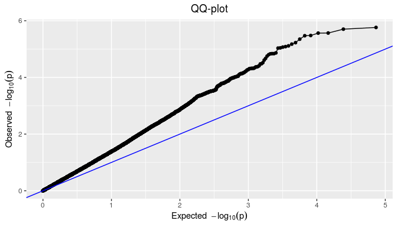

```r
## Plot a qq plot of GWAS Drops.
plot(GWASDrops, plotType = "qq")
```

#### 3.4.2.2 Manhattan plots

A manhattan plot is made by setting `plotType = "manhattan"`. Significant SNPs are marked in red.

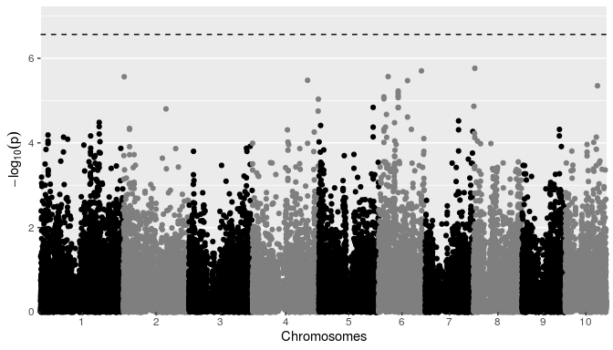

```r
## Plot a manhattan plot of GWAS Drops.
plot(GWASDrops, plotType = "manhattan")
```

More options linked with `plotType = "manhattan"` are described in the statgenGWAS vignette.

#### 3.4.2.3 QTL plots

A qtl plot can be made by setting `plotType = "qtl"`. In this plot the significant SNPs are marked by circles at their genomic positions, with diameter proportional to the estimated effect size; for an example see Millet et al. (2016). Typically, this is done for multiple traits or environments, with the genomic position on the x-axis, which are displayed horizontally above each other and can thus be compared.

Since the traits are measured on a different scale, the effect estimates cannot be compared directly. For better comparison, one can set `normalize = TRUE`, which divides the estimates by the standard deviation of the phenotype.

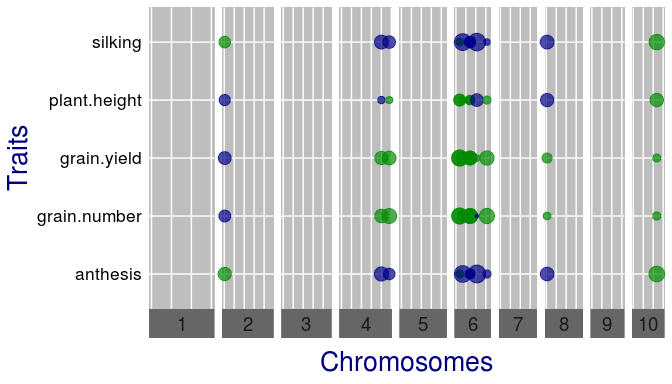

```r
## Plot a qtl plot of GWAS Drops for Mur13W.
## Set significance threshold to 5 and normalize effect estimates.
plot(GWASDrops, plotType = "qtl", yThr = 5, normalize = TRUE)
```

Other parameters can be used to plot a subset of the chromosomes (`chr`) and directly export the plot to .pptx (`exportPptx = TRUE` and specify `pptxName`). Note that the officer package is required for this. A full list of parameters can be found by running `help(plot.GWAS)`.

## 3.5 Kinship matrices

The *runMultiTraitGwas* function has an argument `kinshipMethod`, which defines the kinship matrix used for association mapping. Kinship matrices can be computed directly using the *kinship* function or within the *runMultiTraitGwas* function. There are four options: (1) using the covariance between the scaled SNP-scores (`kinshipMethod = "astle"`, the default; see e.g. equation (2.2) in Astle and Balding (2009)) (2) Identity by State (`kinshipMethod = "IBS"`; see e.g. equation (2.3) in Astle and Balding (2009)) (3) using the formula by VanRaden (2008) (`kinshipMethod = "vanRaden"`) (4) User-defined, in which case the parameter `kin` needs to be specified.

By default, the same kinship matrix is used for testing all SNPs (`GLSMethod = "single"`). When `GLSMethod = "multi"`, the kinship matrix is chromosome-specific. In this case, the function fits variance components and computes effect-estimates and P-values for each chromosome in turn, using the kinship matrix for that chromosome. Each chromosome-specific kinship matrix is computed using the method specified by the argument `kinshipMethod`, using all SNPs that are **not** on this chromosome. As shown by Rincent et al. (2014), this often gives a considerable improvement in power.

```r
## Run multi-trait GWAS for trial 'Mur13W'.
## Use chromosome specific kinship matrices computed using method of van Raden.
GWASDropsChrSpec <- runMultiTraitGwas(gData = gDataDropsDedup,
                                      trials = "Mur13W",
                                      GLSMethod = "multi",
                                      kinshipMethod = "vanRaden",
                                      covModel = "fa")
```

# 4 Worked example: one trait measured in multiple trials

## 4.1 **Create gData object**

In this example, we will focus on one trait, grain yield, in all trials. ´dropsPheno´ contains genotypic means for 28 trials. To be able to run a GWAS analysis with one trait measured in all trials, the data has to be reshaped and added as a single data.frame with “genotype” as first column and traits after that.

```r
## Reshape phenotypic data to data.frame in wide format containing only grain yield.
PhenoDat <- reshape(dropsPheno[,c("Experiment","Variety_ID","grain.yield")],
                    timevar = "Experiment",
                    idvar = "Variety_ID",
                    direction = "wide",
                    v.names = "grain.yield")
## Rename Variety_ID to genotype and other columns with the trial name only.
names(PhenoDat)[1] <- "genotype"
names(PhenoDat)[2:ncol(PhenoDat)] <-  gsub("grain.yield.","",
                                           names(PhenoDat)[2:ncol(PhenoDat)] )
```

Now a gData object containing map marker information and phenotypes can be created. Kinship matrix and covariates may be added later on.

```r
## Create a gData object containing map, marker and phenotypic information.
gDataDropsxE <- createGData(geno = dropsMarkers,
                            map = dropsMap,
                            pheno = PhenoDat)
summary(gDataDropsxE)
```

```
#> map
#>  Number of markers: 41722
#>  Number of chromosomes: 10
#>
#> markers
#>  Number of markers: 41722
#>  Number of genotypes: 246
#>  Content:
#>   0 1 2 NA
#>   0.28 0.01 0.71 0
#>
#> pheno
#>  Number of trials: 1
#>
#>  PhenoDat:
#>      Number of traits: 28
#>      Number of genotypes: 246
#>
#>         Bol12R Bol12W Cam12R Cam12W Cam13R Cam13W Cra12R Cra12W Deb12R Deb12W Deb13R Gai12R Gai12W
#> Min.      0.48   0.34   0.38   0.95    1.9    3.1  0.088    1.6    3.0    3.9    2.7   0.37    7.5
#> 1st Qu.   2.08   3.31   1.33   2.87    3.2    4.7  0.891    3.3    4.9    5.8    5.4   2.11   10.4
#> Median    2.66   4.22   1.87   4.31    3.7    5.4  1.381    4.2    5.4    6.3    5.9   2.94   11.2
#> Mean      2.66   4.11   1.98   4.24    3.7    5.4  1.492    4.2    5.4    6.4    5.9   2.98   11.2
#> 3rd Qu.   3.22   4.90   2.59   5.45    4.2    6.0  1.971    5.0    5.8    7.0    6.5   3.73   12.0
#> Max.      4.74   6.89   4.90   7.95    5.9    8.5  4.979    8.1    7.8    8.8    8.4   6.45   14.3
#> NA's      0.00   0.00   0.00   0.00    0.0    0.0  0.000    0.0    0.0    0.0    0.0   0.00    0.0
#>         Gai13R Gai13W Gra13R Kar12R Kar12W Kar13R Kar13W Mar13R Mar13W Mur13R Mur13W Ner12R Ner12W
#> Min.       5.2    6.6    3.9    6.2    5.4    5.6    4.1    3.8    6.0    2.1    3.3    2.1    4.9
#> 1st Qu.    7.2    9.5    6.1    9.2    8.8    8.7    7.0    7.0    9.6    5.8    6.3    4.0    8.2
#> Median     7.8   10.4    7.0   10.3    9.9    9.8    7.9    7.7   10.6    6.9    7.5    4.7    8.9
#> Mean       7.9   10.4    6.9   10.3    9.7    9.9    8.0    7.8   10.6    6.9    7.4    4.7    8.9
#> 3rd Qu.    8.6   11.3    7.6   11.3   10.7   11.0    9.1    8.6   11.9    7.8    8.4    5.3    9.7
#> Max.      10.5   14.1    9.6   14.2   13.1   13.8   12.7   11.5   14.9   10.6   11.4    7.1   11.8
#> NA's       0.0    0.0    0.0    0.0    0.0    0.0    0.0    0.0    0.0    0.0    0.0    0.0    0.0
#>         Ner13R Ner13W
#> Min.       1.5    4.4
#> 1st Qu.    3.3    7.2
#> Median     3.8    7.9
#> Mean       3.9    7.9
#> 3rd Qu.    4.4    8.8
#> Max.       6.5   11.2
#> NA's       0.0    0.0
```

## 4.2 **Recoding and cleaning of markers**

```r
## Remove duplicate SNPs from gDataDrops.
gDataDropsDedupxE <- codeMarkers(gDataDropsxE, impute = FALSE, verbose = TRUE)
```

```
#> Input contains 41722 SNPs for 246 genotypes.
#> 0 genotypes removed because proportion of missing values larger than or equal to 1.
#> 0 SNPs removed because proportion of missing values larger than or equal to 1.
#> 5098 duplicate SNPs removed.
#> Output contains 36624 SNPs for 246 genotypes.
```

## 4.3 **Multi-trait GWAS**

```r
## Run multi-trait GWAS for one trait in all trials.
GWASDropsxE <- runMultiTraitGwas(gData = gDataDropsDedupxE,
                                 covModel = "fa",
                                 trials ="PhenoDat")
```

```r
head(GWASDropsxE$GWAResult$PhenoDat)
```

```
#>              snp  trait chr    pos pValue  LOD  effect effectSe allFreq
#> 1:         SYN83 Bol12R   1   3498  0.164 0.78 -0.1011    0.058    0.60
#> 2: PZE-101000060 Bol12R   1 157104  0.251 0.60  0.0062    0.061    0.72
#> 3: PZE-101000088 Bol12R   1 238347  0.376 0.42  0.1513    0.073    0.84
#> 4: PZE-101000083 Bol12R   1 239225  0.018 1.74 -0.0784    0.055    0.58
#> 5: PZE-101000108 Bol12R   1 255850  0.358 0.45 -0.1922    0.097    0.90
#> 6: PZE-101000111 Bol12R   1 263938  0.122 0.91  0.0538    0.071    0.83
```

```r
head(GWASDropsxE$signSnp$PhenoDat, row.names = FALSE)
```

```
#>              snp  trait chr       pos  pValue  LOD effect effectSe allFreq       snpStatus
#> 1: PZE-101231758 Bol12R   1 280578622 2.1e-10  9.7  0.324    0.084    0.88 significant SNP
#> 2: PZE-101231883 Bol12R   1 280706431 4.5e-08  7.3  0.277    0.084    0.88 significant SNP
#> 3: PZE-106010241 Bol12R   6  28175590 1.1e-08  8.0  0.062    0.060    0.55 significant SNP
#> 4: PZE-106021363 Bol12R   6  18846283 5.3e-18 17.3  0.050    0.061    0.70 significant SNP
#> 5: PZE-106021410 Bol12R   6  18990291 1.9e-19 18.7  0.044    0.061    0.70 significant SNP
#> 6: PZE-106021419 Bol12R   6  18991091 2.7e-21 20.6  0.071    0.062    0.74 significant SNP
#>    propSnpVar
#> 1:     0.0633
#> 2:     0.0462
#> 3:     0.0055
#> 4:     0.0029
#> 5:     0.0023
#> 6:     0.0055
```

### 4.3.1 GWAS Summary

For a quick overview of the results, e.g. the number of significant SNPs, use the summary function.

```r
summary(GWASDropsxE, traits = c("Ner12W","Cam12W","Gra13R"))
```

```
#> PhenoDat:
#>  Traits analysed: Bol12R, Bol12W, Cam12R, Cam12W, Cam13R, Cam13W, Cra12R, Cra12W, Deb12R, Deb12W, Deb13R, Gai12R, Gai12W, Gai13R, Gai13W, Gra13R, Kar12R, Kar12W, Kar13R, Kar13W, Mar13R, Mar13W, Mur13R, Mur13W, Ner12R, Ner12W, Ner13R, Ner13W
#>
#>  Data are available for 36624 SNPs.
#>   0 of them were not analyzed because their minor allele frequency is below 0.01
#>
#>  Trait: Ner12W
#>
#>      LOD-threshold: 7.3
#>      Number of significant SNPs: 15
#>      Smallest p-value among the significant SNPs: 2.7e-21
#>      Largest p-value among the significant SNPs: 4.5e-08 (LOD-score: 7.3)
#>
#>      No genomic control correction was applied
#>  Trait: Cam12W
#>
#>      LOD-threshold: 7.3
#>      Number of significant SNPs: 15
#>      Smallest p-value among the significant SNPs: 2.7e-21
#>      Largest p-value among the significant SNPs: 4.5e-08 (LOD-score: 7.3)
#>
#>      No genomic control correction was applied
#>  Trait: Gra13R
#>
#>      LOD-threshold: 7.3
#>      Number of significant SNPs: 15
#>      Smallest p-value among the significant SNPs: 2.7e-21
#>      Largest p-value among the significant SNPs: 4.5e-08 (LOD-score: 7.3)
#>
#>      No genomic control correction was applied
```

### 4.3.2 GWAS Plots

The plot.GWAS function can be used to visualize the results in GWASDropsxE, with a QQ-plot, Manhattan plot or QTL-plot. More details for each `plotType` are available in the statgenGWAS vignette.

#### 4.3.2.1 QQ plots

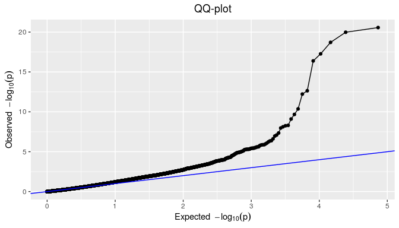

```r
plot(GWASDropsxE, plotType = "qq")
```

#### 4.3.2.2 Manhattan plots

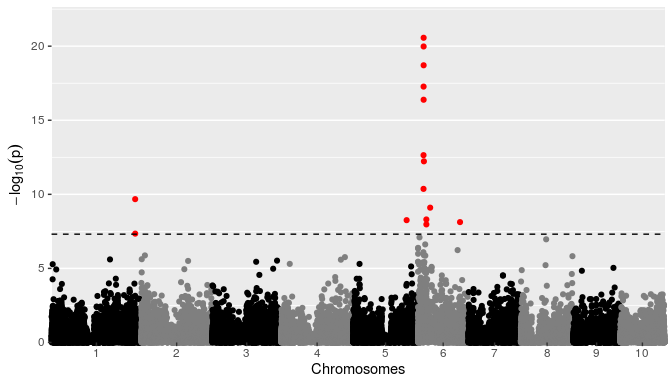

```r
plot(GWASDropsxE, plotType = "manhattan")
```

#### 4.3.2.3 QTL plots

The trait is measured with the same scale across trials so the effect estimates can be compared directly (can set `normalize = FALSE`).

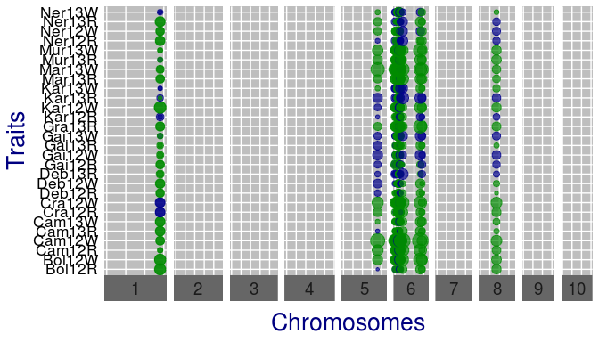

```r
## Set significance threshold to 6 and do not normalize effect estimates.
plot(GWASDropsxE, plotType = "qtl", yThr = 6, normalize = FALSE)
```